# Turkey Dollarization Analysis

##### Oguzhan Pinar - IE360 HW2 - Fall 2020

# 1. Introduction:

Turkey is referred as emerging market in global economy; therefore, there are many global investments in Turkey. Those foreign investments have been an indispensible part of the economy so in every economic decision foreign investors response must be considered carefully. Therefore, during an economic downfall decisions should be made accordingly. However, such decisions are generally creates very high inflation which melts downs wealth of Turkish household. Eventhough interests given to Turkish Lira deposits is very high, it cannot compansate the changes in exchange rates. In response, Turkish household prefers to keep their money in foreign exchange deposits. Which is called dollarization of Turkish Lira.

As the indicator of dollarizaiton I will use the ratio of foreign exchange deposits among all deposits in Turkish banks. This indicator shows the househould's preference between Turkish Lira and foreign currencies, therefore, it can be a good indicator for dollarization. As the data source I will use the database of Turkish Central Bank (https://evds2.tcmb.gov.tr/).

# 2. Analysis:

## 2.1. Import Required Libraries

```python
import pandas as pd
import numpy as np
import datetime as dt
import matplotlib.pyplot as plt
import seaborn as sns
from sklearn.preprocessing import MinMaxScaler

#Set the width of notebook
from IPython.core.display import display, HTML
display(HTML("<style>.container { width:70% !important; }</style>"))
```

## 2.2. Read and Manipulate Data

```python
df = pd.read_excel("EVDS.xlsx",  skipfooter=46)
df.columns = ["date",
                "TRY_interest",
                "USD_interest",
                "USD/TRY",
                "TRY_deposit",
                "foreign_exchange_deposit",
                "total_deposit",
                "consumer_price_index"]
df
```

|  | date | TRY_interest | USD_interest | USD/TRY | TRY_deposit | foreign_exchange_deposit | total_deposit | consumer_price_index |
| --- | --- | --- | --- | --- | --- | --- | --- | --- |
| 0 | 2020-10 | 11.70 | 1.60 | 7.888071 | 1558520879 | 1.964094e+09 | 3.522615e+09 | 487.38 |
| 1 | 2020-09 | 11.08 | 1.49 | 7.521323 | 1576024891 | 1.830295e+09 | 3.406320e+09 | 477.21 |
| 2 | 2020-08 | 9.64 | 1.20 | 7.265250 | 1536588325 | 1.751265e+09 | 3.287853e+09 | 472.61 |
| 3 | 2020-07 | 7.77 | 0.94 | 6.863452 | 1554090985 | 1.624316e+09 | 3.178407e+09 | 468.56 |
| 4 | 2020-06 | 7.76 | 0.93 | 6.821091 | 1521704689 | 1.522947e+09 | 3.044651e+09 | 465.84 |
| ... | ... | ... | ... | ... | ... | ... | ... | ... |
| 89 | 2013-05 | 6.48 | 2.11 | 1.826050 | 541690537 | 2.481307e+08 | 7.898212e+08 | 220.07 |
| 90 | 2013-04 | 6.89 | 2.26 | 1.799690 | 526747584 | 2.466075e+08 | 7.733551e+08 | 219.75 |
| 91 | 2013-03 | 7.04 | 2.28 | 1.810457 | 517550964 | 2.399944e+08 | 7.575454e+08 | 218.83 |
| 92 | 2013-02 | 7.29 | 2.42 | 1.776035 | 508002363 | 2.380725e+08 | 7.460749e+08 | 217.39 |
| 93 | 2013-01 | 7.66 | 2.57 | 1.772368 | 505706390 | 2.405645e+08 | 7.462709e+08 | 216.74 |

94 rows × 8 columns

Now I will manipulate the data to required format.

```
1. Dates are in string format to create time series object I will convert them to "datetime" object and use it as index.
2. In my analysis I will use ratio of foreign exchange deposits in all deposits. Therefore, I will find this ratio.
3. I will calculate monthly inflation rate by finding the percentage change in the consumer price index.
```

```python
### 1. Build time series object ###
df.date = df.date.apply(lambda x: dt.datetime.strptime(x, "%Y-%m"))
df = df.set_index("date")

### 2. Find share of foreign exchange deposits in all deposits ###
df["frgn_deposit_share"] = df.foreign_exchange_deposit /df.total_deposit

### 3. Calculate inflation ###
#We will loose one observation
df["monthly_inflation"] = None
df.iloc[:-1, 8] = (df.consumer_price_index.values[:-1] - df.consumer_price_index.values[1:])/df.consumer_price_index.values[1:]
df = df.iloc[:93]

#drop unnecessary columns:
df = df[["frgn_deposit_share", "monthly_inflation", "USD/TRY", "TRY_interest", "USD_interest"]]

#Fix the format:
df = df.astype(float)

df
```

| date | frgn_deposit_share | monthly_inflation | USD/TRY | TRY_interest | USD_interest |
| --- | --- | --- | --- | --- | --- |
| 2020-10-01 | 0.557567 | 0.021311 | 7.888071 | 11.70 | 1.60 |
| 2020-09-01 | 0.537323 | 0.009733 | 7.521323 | 11.08 | 1.49 |
| 2020-08-01 | 0.532647 | 0.008644 | 7.265250 | 9.64 | 1.20 |
| 2020-07-01 | 0.511047 | 0.005839 | 6.863452 | 7.77 | 0.94 |
| 2020-06-01 | 0.500204 | 0.011333 | 6.821091 | 7.76 | 0.93 |
| ... | ... | ... | ... | ... | ... |
| 2013-06-01 | 0.309480 | 0.007634 | 1.897915 | 6.65 | 2.26 |
| 2013-05-01 | 0.314161 | 0.001456 | 1.826050 | 6.48 | 2.11 |
| 2013-04-01 | 0.318880 | 0.004204 | 1.799690 | 6.89 | 2.26 |
| 2013-03-01 | 0.316805 | 0.006624 | 1.810457 | 7.04 | 2.28 |
| 2013-02-01 | 0.319100 | 0.002999 | 1.776035 | 7.29 | 2.42 |

93 rows × 5 columns

Now check the summary table of the data

```python
df.describe()
```

|  | frgn_deposit_share | monthly_inflation | USD/TRY | TRY_interest | USD_interest |
| --- | --- | --- | --- | --- | --- |
| count | 93.000000 | 93.000000 | 93.000000 | 93.000000 | 93.000000 |
| mean | 0.427088 | 0.008794 | 3.815250 | 12.134946 | 2.466667 |
| std | 0.065391 | 0.009377 | 1.659428 | 4.377307 | 0.789458 |
| min | 0.309480 | -0.014429 | 1.776035 | 6.480000 | 0.930000 |
| 25% | 0.378804 | 0.003517 | 2.332538 | 9.640000 | 1.970000 |
| 50% | 0.420046 | 0.007433 | 3.474295 | 10.850000 | 2.370000 |
| 75% | 0.491704 | 0.013450 | 5.383173 | 12.830000 | 3.030000 |
| max | 0.557567 | 0.063047 | 7.888071 | 24.310000 | 4.950000 |

Summary tables are generally good the see the problems in the data. When we observe it, we don't see any problematic value in the summary table. Therefore, we can continue our analysis by visualizing the data.

## 2.3. Visualize the Data

In order to observe dollarizaiton level in Turkey and how is it changed over time, I will first draw lineplot of foreign exchange deposit share.

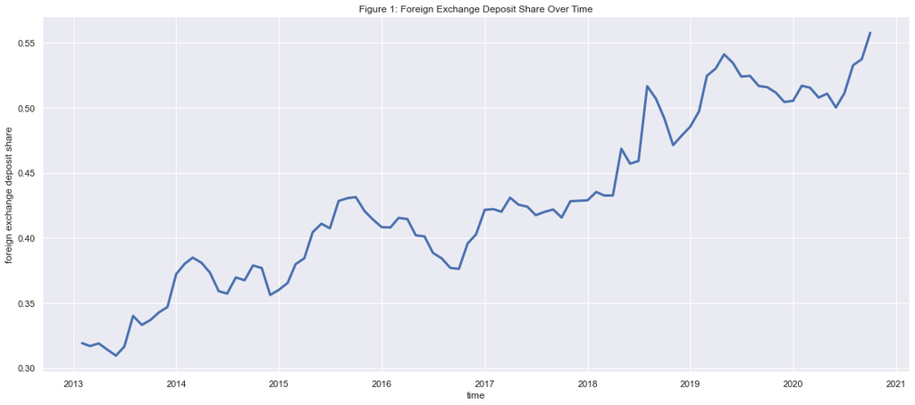

```python
#Set the figure size:
sns.set(rc={'figure.figsize':(19,8)})

ax = sns.lineplot(data=df["frgn_deposit_share"], linewidth=3)
ax.set(xlabel='time', ylabel='foreign exchange deposit share', title="Figure 1: Foreign Exchange Deposit Share Over Time")
plt.show()
```

From the Figure 1, we can clearly observe the rise of foreign exchange deposit shares which was approximately 32% in 2013 but the level is above 55% now. In other words, more than 55% of Turkish households money kept in banks is in foreign currency right now. This situation reveals the existence of dollarization.

Now, in order to inspect the impacts of our features on dollarizaiton, I will draw the line plots of them with Foreign Exchange Deposit Share. Lineplots are perfect tools to inspect the lagged realtionships between the varibles. However, in our data the scale of columns are very different which makes movements of some features invisible. To prevent this, I will first scale my data between 0 and 1 without changing the distribution or any other characteristics of data. Scaling is going make the visual analysis easier and since we are only interested in movements of the data, and not much interested in values, there won't be any cost of scaling.

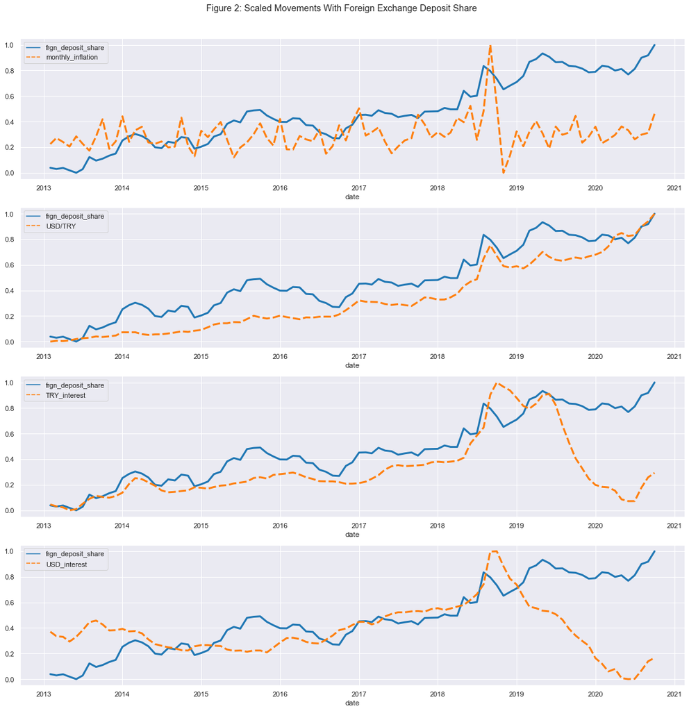

```python
#Scale the data:
scaler = MinMaxScaler()
scaler.fit(df)
scaled_df = pd.DataFrame(scaler.transform(df))
scaled_df.index = df.index
scaled_df.columns = df.columns

#Set the figure size:
sns.set(rc={'figure.figsize':(19,19)})

#Divide the figure:
fig, axs = plt.subplots(4,1)
fig.suptitle('Figure 2: Scaled Movements With Foreign Exchange Deposit Share', y = 0.92)

#Plot each variable with frgn_deposit_share
sns.lineplot(data=scaled_df[["frgn_deposit_share", "monthly_inflation"]], palette="tab10", linewidth=3, ax = axs[0])
sns.lineplot(data=scaled_df[["frgn_deposit_share", "USD/TRY"]]          , palette="tab10", linewidth=3, ax = axs[1])
sns.lineplot(data=scaled_df[["frgn_deposit_share", "TRY_interest"]]     , palette="tab10", linewidth=3, ax = axs[2])
sns.lineplot(data=scaled_df[["frgn_deposit_share", "USD_interest"]]     , palette="tab10", linewidth=3, ax = axs[3])
```

[output not shown]

## 2.4. Calculate Correlations and Draw Correlation Heatmap

Now I will include 3 lags to each data and calculate the correlations which will include autocorrelations of where max lags is 3. Then I will draw correlation heatmap:

```python
df_l1 = df.shift(-1)
df_l1.columns = ("L1_" + df.columns)
df_l2 = df.shift(-2)
df_l2.columns = ("L2_" + df.columns)
df_l3 = df.shift(-3)
df_l3.columns = ("L3_" + df.columns)

lagged_df = df.merge(df_l1, how="inner", left_index=True, right_index=True).merge(df_l2, how="inner", left_index=True, right_index=True).merge(df_l3, how="inner", left_index=True, right_index=True).dropna()

#Fix the order of columns to get a better correlation map:
lagged_df = lagged_df[['frgn_deposit_share', 'L1_frgn_deposit_share', 'L2_frgn_deposit_share', 'L3_frgn_deposit_share',
                       'USD/TRY'           , 'L1_USD/TRY'           , 'L2_USD/TRY'           , 'L3_USD/TRY',
                       'TRY_interest'      , 'L1_TRY_interest'      ,  'L2_TRY_interest'     , 'L3_TRY_interest',
                       'USD_interest'      ,  'L1_USD_interest'     ,  'L2_USD_interest'     , 'L3_USD_interest',
                       'monthly_inflation' , 'L1_monthly_inflation' , 'L2_monthly_inflation' , 'L3_monthly_inflation']]
```

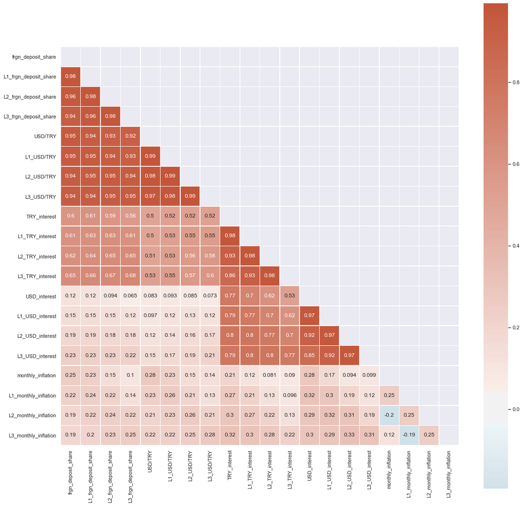

```python
# Compute the correlation matrix
corr = lagged_df.corr()
# Draw the heatmap with the mask and correct aspect ratio

mask = np.triu(np.ones_like(corr, dtype=bool)) # Mask for the upper triangle
f, ax = plt.subplots(figsize=(19, 19))
sns.heatmap(corr, mask=mask, cmap=sns.diverging_palette(230, 20, as_cmap=True), annot=True, center=0, square=True, linewidths=.5)
```

# 3. Conclusion:

In this work I have analyzed dollarization of Turkey in last 7 years. For the dollarization measure, Foreign Exchange Deposit Share in Turkish banks is used. I have first shown that Foreign Exchange Deposit Share have a rising trend and have risen up to 55% nowadays which was around 32% in 2013. Then some related feauteres and their correlations with Foreign Exchange Deposit Share is analyzed. Firstly, USD/TRY is found to have the closest relationship with Foreign Exchange Deposit Share and therefore with dollarization. Second finding is, counter-intuitevly, interest given Turkish could not succeed to turn Turkish household buying dollars. The reason behind this might be the very strong rise in USD/TRY exchange rate could not be compansated by Lira interest. For interest given USD in Turkish banks and monthly inflation we found positive but weak correlations.